# bupaRflow tutorial

In this tutorial, we explain the use of bupaRflow by creating the following analyses.

- A process map showing the frequency of flows in the patients dataset.
- A process map showing the duration of flows and activities.
- An overview of the traces (process variants) covering 90% of the data.
- A graph of the throughput time of said traces.

Using normal bupaR code, these can be done as follows.

```r
patients %>%
    process_map(frequency())

patients %>%
    process_map(performance())

patients %>%
    filter_trace_frequency(percentage = 0.9) %>%
    trace_explorer(coverage = 1)

patients %>%
    filter_trace_frequency(percentage = 0.9) %>%
    throughput_time() %>%
    plot()
```

bupaRflow can be accessed by the following link: buparflow.azurewebsites.net/. In the pop-up that appears, select the option *Proceed without an account*.

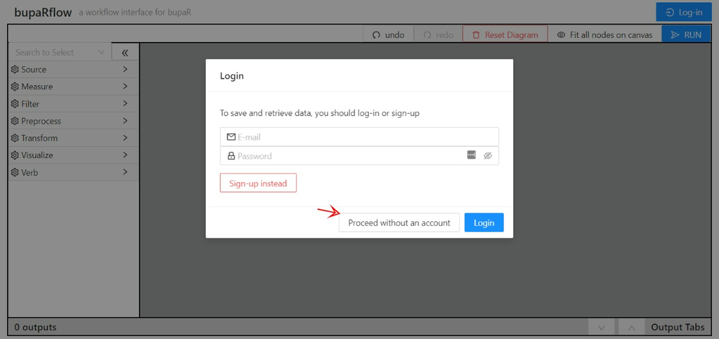

We can now start adding objects on our canvas. The available objects can be found on the left, under different categories. From the source category, take the “patients” block. This is one of the built-in example event logs that comes with bupaR. If you click on it in the left pane, the block will appear on your canvas. You can always delete blocks from the camvas by holding SHIFT and clicking on the block you want to delete.

Let’s also add the *filter trace frequency* block. You find this under the category “filters”. We can now connect the output port of the patients block with the input port of the filter block. To do so, click on any of both ports, and drag your mouse to the other port. You will see an arrow appear.

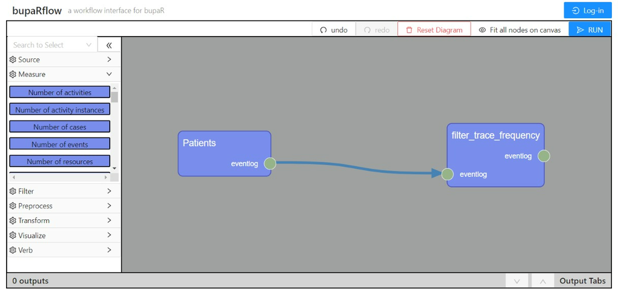

Before we can run this workflow, we need to configure the filter function. To that end, double click on the block to open the configuration pane. As we want to keep 90% of the log containing the most common process variants, fill in the percentage field as shown below. Then click “Save Inputs”.

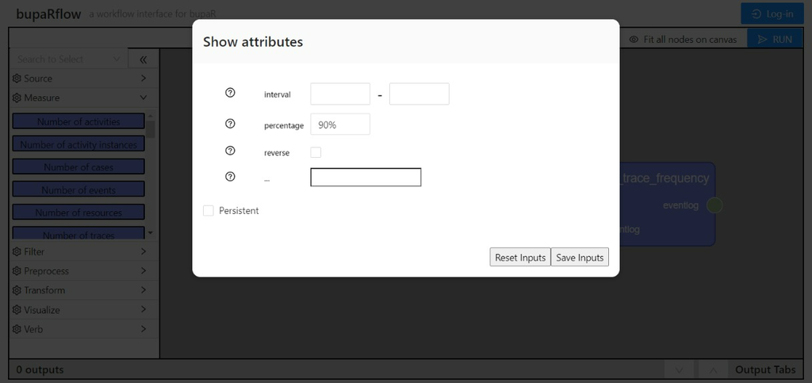

We now have created our first workflow and can click on the run button in the upper right corner. Our first analysis results will then appear in the lower part of the application.

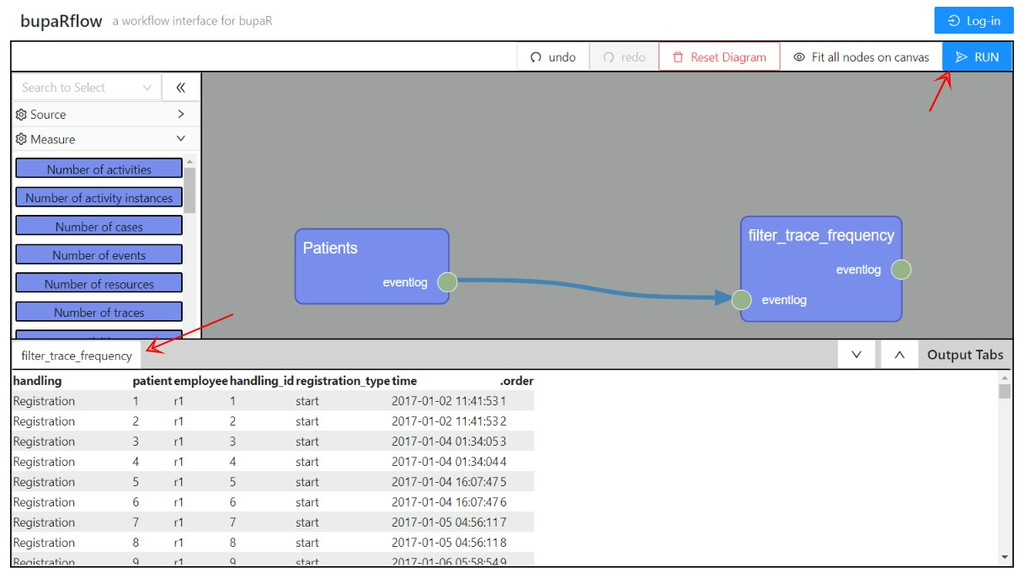

The original dataset contains 500 cases. In order to check that we have indeed obtained 90% of the log, let’s calculate the number of cases in the log after the filtering step. To do this, add the “Number of cases” block, and connect it to the filter block. The Run the workflow again.

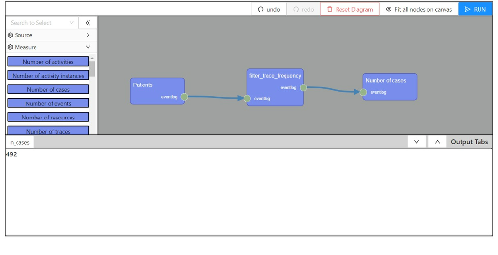

We see that 492 cases are still in the data. Note that this is more than 90% of 500 because of a tie in the data. The filter function will always return *at least* the specified amount, and will not divide the log arbirtrarily.

Let’s look at the traces that are in this log, by adding the *trace explorer* block, and connecting it again to the ouput port of the filter block. You will find this function under the Visualize tab on the left. Then, set the coverage argument in the trace explorer block to 1. Recall that you can open the configuration pane by double-clicking on the function.

If you click on the Run button again, the trace explorer visualization will appear. You can enlarge it by using the arrow on the right (indicated in the figure below), or by clicking on the image.

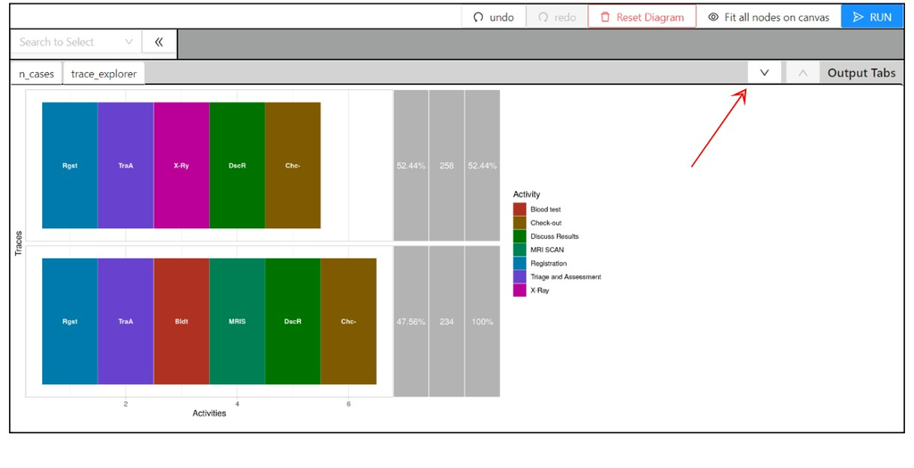

We have now completed on of the workflows we set out to do. Let’s complete an other one by adding the *throughput time* block and the *plot* block. The *throughput time* block can be found in the Measure tab, whereas the *plot* function can be found again under Visualize (minimize the output ribbon if needed). Both of them do not need any parameters, so we can click run, and you’ll see a boxplot of the throughput time.

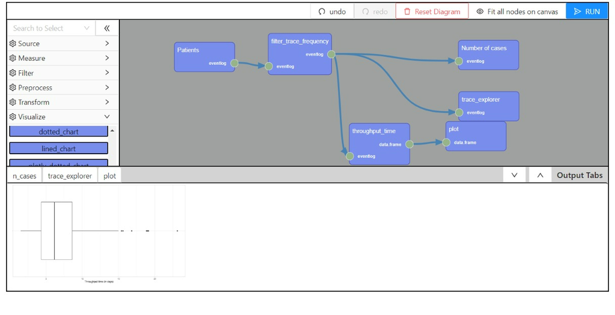

Finally, let’s create two process maps. The process map block can be found under Visualize as well. As you can see, the process map block requires a second input, which defines the *type* of the process map. This can either be frequency or performance. To configure the type, also add the *process map configuration* block on the canvas, and connect it. Double click on the *process map configuration* block to check out its different configurations. Lets add two process maps. One with a frequency configuration, and one with a performance configuration. Our canvas now looks as follows.

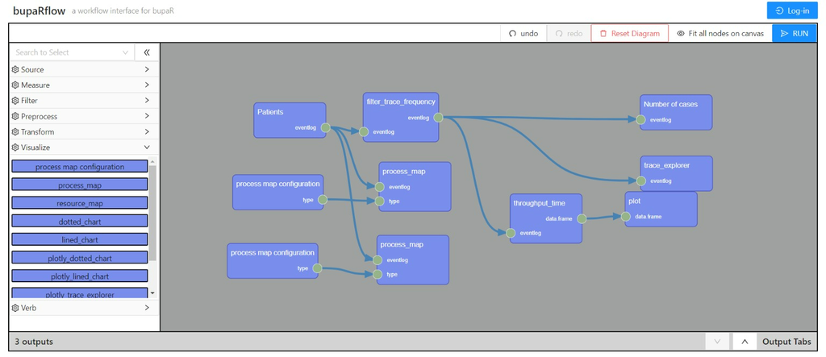

When clicking run, 5 different outputs will appear. In any case, click on the visualization to enlarge it, and right click to download it to your pc.